# Case Study - Health Care dataset

Data privacy on a new dataset  
Health care provider  
"Machine learning" on this dataset

- To predict the **has_diabetes** according to the features at hand
- To figure out if there are **preventive measures** that can be taken
  - so **fewer** patients are seen in the hospital for related care or
  - so that their visits are **shorter**
- More potentially **affected patients** given access to
  - primary care physicians and regular medication or
  - visits that can keep them out of the hospital for long stays

## Determining What's Useful and What's Sensitive

- Data completeness
- Potential sensitive columns
- Potential useful features
- What columns should we use?
- Which ones should we remove?
- Are there columns which we should protect but not remove?

### Data completeness

```python
print(df.isna().sum().sum() / df.size * 100)
```

```
0.0
```

```python
df.isnull().any().any()
```

```
False
```

The data is **complete** as there are no null value nor missing value.

### Potential sensitive columns

**Medically related** potential sentive columns:

- admitted_ts,
- ambulance_call,
- blood_sugar_reading,
- days_since_last_visit,
- has_diabetes,
- hospital,
- hours_hospitalized,
- hydration_level,
- insulin,
- private_insurance,
- released_sameday and
- symptom_code

**Potential** sensitive: no_primary_dr

**Personal** identifiable or quasi identifiable:

- id,
- patient_name and
- ssn

### Potential usefull features

We're going to **analyze principal components** of a predictive model in order to evaluate potential usefull features.  
To do so, we're start fitting a baseline model just to fit correlation between the target and the rest of the features.

Let's check **correlations** to focus on useful data.  
To do so, we would **numerical** columns so let's do the necessary transformations..

```python
# drop categorical columns not correlated to target or that can cause leakage
pca_ddf = dummy_df.drop(
    ['admitted_ts', 'patient_name', 'ssn', 'id'], axis=1)
```

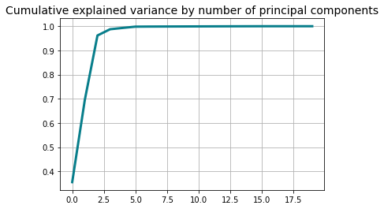

```python
plt.plot(pca.explained_variance_ratio_.cumsum(), lw=3, color='#087E8B')
plt.title(
    'Cumulative explained variance by number of principal components', size=14)
plt.grid()
plt.show()
```

```python
loadings = pd.DataFrame(
    data = pca.components_.T * np.sqrt(pca.explained_variance_),
    columns=[f'PC{i}' for i in range(1, len(X_train.columns) + 1)],
    index=X_train.columns
)
loadings.head()
```

|  | PC1 | PC2 | PC3 | PC4 | PC5 | PC6 | PC7 | PC8 | PC9 | PC10 | PC11 | PC12 | PC13 | PC14 | PC15 | PC16 | PC17 | PC18 | PC19 | PC20 |
| --- | --- | --- | --- | --- | --- | --- | --- | --- | --- | --- | --- | --- | --- | --- | --- | --- | --- | --- | --- | --- |
| age | -9.066559 | 1.964975 | -18.651862 | -0.036933 | 0.035986 | -0.031850 | 0.000334 | 0.000133 | 0.000071 | 0.000301 | 0.000590 | 0.000679 | 0.000069 | -0.000158 | 0.000089 | -0.000268 | -0.000505 | 8.806542e-35 | 1.040696e-34 | 1.994475e-35 |
| ambulance_call | 0.007441 | -0.005562 | 0.019056 | -0.013956 | -0.019021 | 0.013097 | 0.021348 | 0.087779 | -0.141519 | -0.015333 | 0.360163 | 0.139155 | -0.217348 | -0.141246 | 0.009954 | 0.065325 | 0.002527 | 1.436919e-32 | -1.085483e-32 | 1.888617e-33 |
| blood_sugar_reading | 16.968793 | -13.595883 | -7.282174 | 0.032685 | 0.010484 | 0.010903 | -0.001614 | -0.000788 | -0.000155 | 0.000160 | 0.000401 | -0.000645 | 0.000161 | -0.000294 | 0.000148 | -0.000107 | -0.000035 | 2.692032e-34 | -4.119806e-35 | 1.858369e-34 |
| days_since_last_visit | 13.481297 | 18.435795 | -3.381108 | 0.012062 | 0.011305 | 0.004352 | -0.000361 | 0.000514 | -0.000494 | 0.000300 | 0.000089 | -0.000636 | -0.000335 | 0.000167 | 0.000017 | -0.000401 | -0.000034 | 1.353423e-34 | 4.120457e-35 | -1.627916e-34 |
| hours_hospitalized | -0.164652 | 0.046918 | -0.067290 | 6.321838 | -0.051345 | -0.001798 | -0.000381 | 0.001541 | -0.000462 | -0.001282 | -0.000018 | -0.000103 | -0.001446 | 0.001406 | -0.000170 | 0.004096 | -0.016342 | -8.816816e-34 | 1.275635e-33 | 3.553209e-34 |

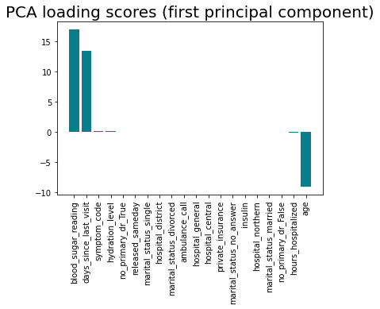

```python
pc1_loadings = loadings.sort_values(by='PC1', ascending=False)[['PC1']]
pc1_loadings = pc1_loadings.reset_index()
pc1_loadings.columns = ['Attribute', 'CorrelationWithPC1']

plt.bar(
    x=pc1_loadings[
        'Attribute'], height=pc1_loadings[
            'CorrelationWithPC1'], color='#087E8B')
plt.title('PCA loading scores (first principal component)', size=20)
plt.xticks(rotation='vertical')
plt.show()
```

### Columns to use

Those feature **make indeed sense** from our understanding of diabetes.

### Columns to remove

We should remove the **unique identifiers** that can cause leakage and identify a person:

- id,
- ssn,
- patient_name.

### Columns to protect

The potential sensitive **medical** columns correlated should be protected:

- ambulance_call,
- blood_sugar_reading,
- days_since_last_visit,
- has_diabetes,
- hours_hospitalized,
- hydration_level,
- insulin,
- private_insurance,
- released_sameday and
- symptom_code.

## Determining the Approach for protecting the Columns

**What methods will be most effective?**

We will:

- remove personal information
- protect sensitive information
- send only the **most relevant data first**

**Have you considered potential data leakage within *non-sensitive* columns?**

We have considered potential data leakage within non-sensitive columns but the riskier leakage came from id (sensitive), as it's a **unique value** that can cause overfitting.

**Is there other sensitive or secret data we should address?**

The dataset is not concerned by any other non medical sensitive or secret information such as salary or geolocation.  
**`hospital`** could have been discussed but as it's medical, it has already been taken into account.

## Implement Data Protection for the Dataset

**What was difficult to decide and implement?**

Methods to chose,  
Data to

- remove,
- protect and at Step to implement it all.

**Laplace transformation**

- convenient for numeric data we were dealing with,
- reasonable tradeoff between
  - utility and
  - privacy for our usecase and
- scalable.

Removed all the data that wouldn't statistically have a **significant impact** on our model.

The questions helped track the steps where to transform data.

**How might this relate to real problems in machine learning with sensitive data?**

This might relate to real problems such as an hospital having to decide which data to duplicate from their **production environment to their development** environment within their datahub so that a data team could work with it for example.

### Machine learning from anonymized Dataset

Build a model that predicts the the diabetes statue of a new patient based on the anonymized database

Compare with non anonymized dataset. (try to get more than 0.65 accuracy)

```python
# Train a baseline logistic regression
diabetes_check = LogisticRegression(max_iter=1000)
#diabetes_check.fit(X_train, y_train)
diabetes_check.fit(train_Xm, train_y)
```

```
LogisticRegression(max_iter=1000)
```

```python
score = diabetes_check.score(test_Xm, test_y)
print("Test Accuracy Score", score)
```

```
Test Accuracy Score 0.76
```

```python
# Train a baseline logistic regression
comparison_check = LogisticRegression(max_iter=1000)
comparison_check.fit(X_train, y_train)

comparison_score = comparison_check.score(X_test, y_test)
print("Comparison Accuracy Score", comparison_score)
```

```
Comparison Accuracy Score 0.76
```

Same test accuracy score, no matter we use anonymized or non anonymized dataset.

Introducing non protected features didn't change accuracy: Laplace mechanism **correctly anonymized** the dataset.

It confirms our conclusion at the previous notebooks:

- **privacy increase can have either reduce or maintain accuracy**
- the accuracy of the model
  - depends on the privacy **method** and the distribution of the features,
  - not on the actual values

### [Intelligence Artificielle et Sciences des Données](https://neohack22.github.io/iasd.github.io/ROBUST_presentation_2.slides.html)

#### Published by:

Abdoulaye DOUCOURE/ Frédéric LEITE

#### Reviewed by:

Dario COLAZZO/ Alexandre VERINE/ Tristan CAZENAVE